# SIPP EDA

Author

Sarah Krause

# Read in the SIPP data

For this section of the code, I have just copied from the snap_microsim file to read in all the files and aggregate the SIPP vars to the household level.

```r
#Load the "data.table", "dplyer", and "bit64" libraries
library(data.table)
library(bit64)
library(dplyr)
library(haven)
library(ggplot2)
library(tidyr)
library(readxl)
```

```r
ds <- c("data/pu2019.csv")

# Step 1: Read all named columns plus pattern-matched ones
all_cols <- names(fread(ds, sep = "|", nrows = 0))
```

```r
exact_vars <- c(
  # ID variables
  'SSUID', 'PNUM', 'MONTHCODE', 'ERESIDENCEID', 'ERELRPE', 'SPANEL', 'SWAVE',
  'SHHADID', 'THHLDSTATUS', 'RIN_UNIV',

  # Base weight
  'WPFINWGT',

  # State of residence
  'TEHC_ST', 'TST_INTV',

  # Demographics
  'ESEX', 'TAGE', 'TAGE_EHC', 'ERACE', 'EORIGIN', 'EEDUC',
  'ECITIZEN', 'ENATIVITY', 'EIMM_STAT',
  'EDISABL', 'RDIS', 'RDIS_ALT',

  # Household structure
  'TLIVQTR', 'ETENURE', 'EMS',

  # Income
  'TPTOTINC', 'TPEARN', 'TFTOTINC',
  'TUNEMP_AMT', 'TSSI_AMT', 'TSSRX', 'TSSXAMT', 'TTANF_AMT',

  # Deductions
  'TAMOUNTPAID', 'TPAYWK', 'TRENTMORT', 'TUTILS', 'THVAL_RMU',
  'TCHCARE_AMT', 'TMDPAY',

  # Assets (individual-level; shared assets divided equally)
  'TVAL_AST', 'TVAL_BANK', 'TVAL_BOND', 'TVAL_BUS', 'TVAL_ESAV',
  'TVAL_HOME', 'TVAL_RENT', 'TVAL_RE', 'TVAL_RET',
  'TVAL_STMF', 'TVAL_VEH', 'TVAL_OTH',

  # Program participation
  'RFSCOV', 'RSNAP_MNYN', 'RTANF_MNYN', 'RSSI_MNYN', 'RWICYN',

  # ABAWD work requirement variables
  'TMWKHRS', 'EWELACTV2_1', 'EWELACTV2_2', 'EWELACTV2_3', 'EWELACTV4'
)

patterns <- c(
  "^RREL", "^ET2REL", "^SNAP", "^TEHC",
  "^EOWN", "^EJSOWN", "^EJOOWN", "^EOOWN",
  "^TJS", "^TJO", "^VAL", "^EVEH", "^TVEH"
)

pattern_vars <- unique(unlist(lapply(patterns, function(p) grep(p, all_cols, value = TRUE))))
keep_vars    <- unique(c(exact_vars, pattern_vars))
keep_vars    <- keep_vars[keep_vars %in% all_cols]

pu <- fread(ds, sep = "|", select = keep_vars)
names(pu) <- toupper(names(pu))

dw <- "data/rw2019.csv"
rw <- fread(dw, sep = "|")
names(rw) <- toupper(names(rw))

sipp2019 <- left_join(pu, rw, by = c("SSUID", "PNUM", "MONTHCODE"))
```

```r
# Filter to July 2019
sipp_0719 <- sipp2019 |>
  filter(RIN_UNIV == 1 & MONTHCODE == 7) |>
  mutate(hhid = paste0(as.character(SSUID), as.character(SHHADID))) |>
  group_by(hhid) |>
  mutate(snap_split = ERELRPE %in% 16:18, # splitting cases that are roommates/boarders/other non-family into separate SNAP unit
         split_id = if_else(snap_split, cumsum(snap_split), NA_integer_),
         snapuid = case_when(!snap_split ~ 1,
         snap_split ~ split_id + 1)
) |> ungroup() |>
  mutate(snap_hhid = paste0(hhid, snapuid))

# Brief checks to make sure split went correctly
sipp_0719 |>
  group_by(hhid) |>
  summarise(n_snap_units = n_distinct(snap_hhid)) |>
  count(n_snap_units)
```

```
# A tibble: 8 × 2
  n_snap_units     n
         <int> <int>
1            1 20191
2            2   533
3            3   112
4            4    36
5            5    14
6            6     6
7            7     1
8            8     1
```

```r
sipp_0719 |>
  group_by(hhid) |>
  filter(n_distinct(snap_hhid) > 1) |>
  arrange(hhid, snap_hhid) |>
  select(hhid, ERELRPE, snap_hhid) |>
  ungroup() |>
  slice_head(n = 50)
```

```
# A tibble: 50 × 3
   hhid             ERELRPE snap_hhid
   <chr>              <int> <chr>
 1 2850346461811          2 28503464618111
 2 2850346461811         16 28503464618112
 3 2920499955501811       2 29204999555018111
 4 2920499955501811      18 29204999555018112
 5 2921360681981811       1 29213606819818111
 6 2921360681981811       4 29213606819818111
 7 2921360681981811       7 29213606819818111
 8 2921360681981811      18 29213606819818112
 9 2921363345521811       1 29213633455218111
10 2921363345521811       7 29213633455218111
# ℹ 40 more rows
```

```r
snapdb <- read_xlsx("data/SNAPPolicyDatabase.xlsx", sheet = "SNAP Policy Database") |>
  filter(yearmonth == 201907) |>
  select(starts_with("state"), starts_with("bbce"), starts_with("veh"))

# Work requirement tiers based on FY2019 Q4 ABAWD waiver status
state_exempt <- c("Alaska", "District of Columbia", "Louisiana", "New Mexico")

state_nonexempt <- c("Alabama", "Arkansas", "Delaware", "Florida", "Indiana",
                     "Iowa", "Kansas", "Maine", "Mississippi", "Missouri",
                     "Nebraska", "North Carolina", "Oklahoma", "South Carolina",
                     "Texas", "Wisconsin", "Wyoming")

snapdb <- snapdb |>
  mutate(work_req = case_when(
    statename %in% state_exempt ~ "full_exemption",
    statename %in% state_nonexempt ~ "no_exemption",
    TRUE ~ "partial_exemption"))
```

```r
# Aggregation
hh_sipp <- sipp_0719 |>
  group_by(snap_hhid) |>
  summarize(
    hh_size = n(),
    # Flags for exemptions
    has_elderly = any(TAGE >= 60, na.rm = TRUE),
    has_disabled = any(RDIS == 1, na.rm = TRUE),
    has_ssi = any(RSSI_MNYN == 1, na.rm = TRUE),
    has_tanf = any(RTANF_MNYN == 1, na.rm = TRUE),
    # Income
    hh_gross_inc = sum(TPTOTINC, na.rm = TRUE),
    hh_earn = sum(TPEARN, na.rm = TRUE),
    # Deductions
    child_sup_ded = sum(TAMOUNTPAID, na.rm = TRUE),
    child_care_ded = first(TPAYWK[!is.na(TPAYWK)], default = 0) * 4,
    medical_costs = sum(TMDPAY, na.rm = TRUE),
    # Shelter (December of reference year as proxy)
    shelter_costs = coalesce(first(na.omit(THVAL_RMU)), 0),
    # Countable assets — exclude home, retirement, educational savings
    countable_assets = sum(TVAL_BANK, na.rm = TRUE) + sum(TVAL_BOND, na.rm = TRUE) +
                       sum(TVAL_BUS,  na.rm = TRUE) + sum(TVAL_STMF, na.rm = TRUE) +
                       sum(TVAL_RENT, na.rm = TRUE) + sum(TVAL_RE,   na.rm = TRUE) +
                       sum(TVAL_OTH,  na.rm = TRUE),
    vehicle_assets = sum(TVAL_VEH, na.rm = TRUE),
    # Household-level vehicle values for state exclusion rules
    tveh1_val = first(TVEH1VAL),
    tveh2_val = first(TVEH2VAL),
    tveh3_val = first(TVEH3VAL),
    # ABAWD flags — computed at person level, aggregated to household
    has_children = any(TAGE < 18, na.rm = TRUE),
    has_abawd_age = any(TAGE >= 18 & TAGE <= 49 & RDIS != 1, na.rm = TRUE),
    abawd_meets_work = any(
      (TAGE >= 18 & TAGE <= 49 & RDIS != 1) & (TMWKHRS >= 20), na.rm = TRUE),
    has_any_citizen = any(ECITIZEN %in% c(1L, 2L), na.rm = TRUE), # confirm this
    state_fips = first(TEHC_ST),
    weight = first(WPFINWGT),
    snap_actual = any(RSNAP_MNYN == 1, na.rm = TRUE)
  ) |>
  # joining in snap eligibility rules
  left_join(snapdb, by = "state_fips")
```

# EDA

First, how many individuals and households are there in SIPP?

```r
# Number of unique individuals
sipp_0719 |>
  distinct(paste(SSUID, PNUM)) |>
  count()
```

```
# A tibble: 1 × 1
      n
  <int>
1 49229
```

```r
# Number of unique households
sipp_0719 |>
  distinct(snap_hhid) |>
  count()
```

```
# A tibble: 1 × 1
      n
  <int>
1 21858
```

## Individual-level missingness

We are interested in seeing the level of missingness in the variables we will be using for our microsimulation.

```r
microsim_vars <- sipp_0719 |>
  # Select the variables we use in our microsimulation
  select(snap_hhid, ERELRPE, PNUM, TAGE, RDIS, RSSI_MNYN, RTANF_MNYN,
         TPTOTINC, TPEARN, TAMOUNTPAID, TPAYWK,
         TMDPAY, THVAL_RMU, starts_with("TVAL"), TVEH1VAL, TVEH2VAL, TVEH3VAL,
         TMWKHRS, ECITIZEN, TEHC_ST, WPFINWGT, RSNAP_MNYN)

# Skim the variables to get a summary
library(skimr)
vars_skimmed <- skimr::skim(microsim_vars) |>
  arrange(complete_rate)

# Examine the number missing and complete rate for each variable
vars_skimmed |>
  select(skim_variable, n_missing, complete_rate) |>
  print()
```

```
# A tibble: 33 × 3
   skim_variable n_missing complete_rate
   <chr>             <int>         <dbl>
 1 TAMOUNTPAID       48600        0.0128
 2 TPAYWK            47900        0.0270
 3 TVEH3VAL          38280        0.222
 4 TMWKHRS           26951        0.453
 5 TPEARN            26949        0.453
 6 TVEH2VAL          21874        0.556
 7 TVAL_AST           8556        0.826
 8 TVAL_BANK          8556        0.826
 9 TVAL_BOND          8556        0.826
10 TVAL_BUS           8556        0.826
# ℹ 23 more rows
```

TAMOUNTPAID (amount of child support paid), TPAYWK (amount paid for childcare during a typical week), and TVEH3VAL (value of the 3rd vehicle in the household) have over 70% of the variable missing at the individual level. This is not surprising, because we would expect that most families in the SIPP do not pay child support or own 3 vehicles. The high level of missingness for TPAYWK is more surprising.

Perhaps TPAYWK is missing at a high rate because the question is asked to only the reference parent, so the others in the household would have missing values because they are not in universe.

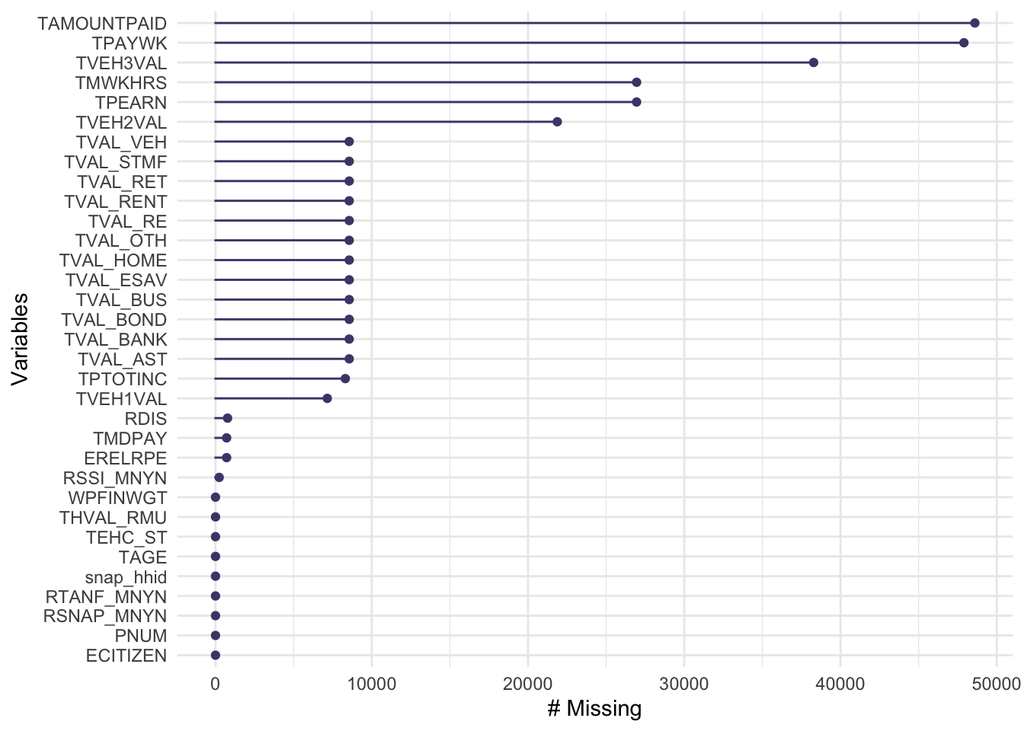

```r
library(naniar)
# Visualize =missingness across all variables
gg_miss_var(microsim_vars)
```

This is good information to have, but our microsimulation is occurring at the household level. Next we examine missingness of variables for households (how many households are compoltely missing a value for our key variables).

This will help us understand what variables would be candidates for substitution or KNN. For example, missing a lot of child support information is to be expected because not everyone pays child support, but if we’re missing asset information at the household level, that might be more of a problem for the precision of our simulation.

## Household-level missingness

First, how many households are missing all values of each variable?

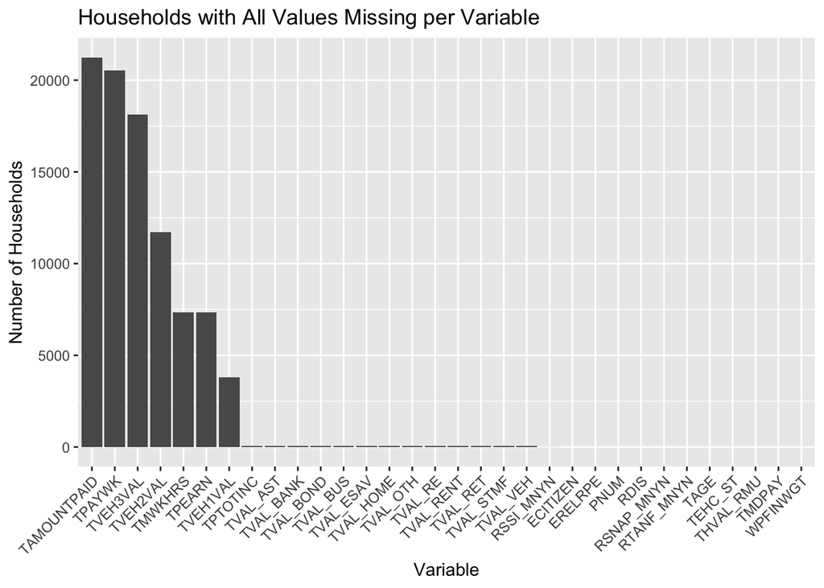

```r
microsim_vars |>
  group_by(snap_hhid) |>
  summarize(across(everything(), ~ all(is.na(.x)))) |>  # TRUE if all members missing
  summarize(across(-snap_hhid, sum)) |>                      # count households where TRUE
  pivot_longer(everything(), names_to = "variable", values_to = "n_hh_missing") |>
  ggplot(aes(x = reorder(variable, -n_hh_missing), y = n_hh_missing)) +
  geom_col() +
  labs(
    x = "Variable",
    y = "Number of Households",
    title = "Households with All Values Missing per Variable"
  ) +
  theme(axis.text.x = element_text(angle = 45, hjust = 1))
```

When we aggregate, this will not be a problem because NA’s will be treated as 0’s. So households that are missing a value for any of these variables will be coded as 0 at the household level. Because of the definitions of these variables, this is an accurate representation. For example, for TPEARN, the universe is individuals who reported having at least one job during the reference month. If they had no job that month, then their earnings from jobs should be coded as 0.

We are interested in how many individuals in a household are missing values for our key variables. Next, we write a custom function to obtain a histogram of individual missingness at the household level, which will help us visualize: for each household, what percent of members are missing for a variable

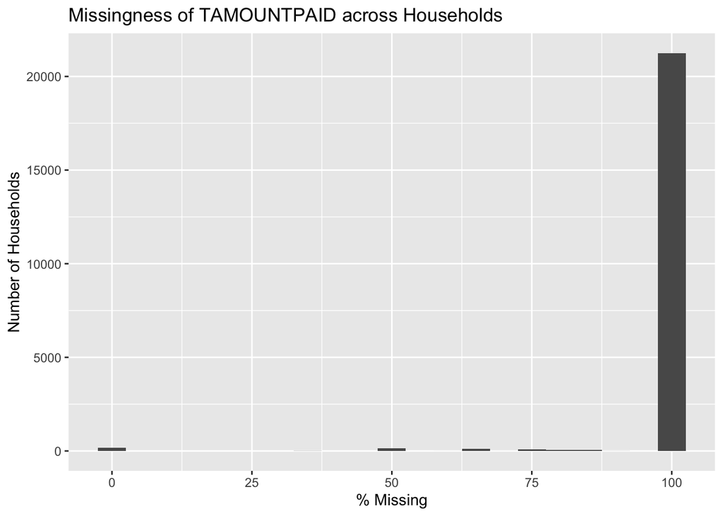

```r
# Houshold missingness histogram function
#' Title: For each household, what percent of members are missing for a variable
#'
#' @param data = the data to be used
#' @param var = the variable you want to visualize
#' @param hh_id = the household id variale to group by
#'
#' @returns a histogram with % missing on the x axis and number of households on the y
#' @export
#'
hh_miss_hist <- function(data, var, hh_id) {
    data |>
    group_by({{ hh_id }}) |>
    summarize(pct_missing = mean(is.na({{ var }})) * 100) |>
    ggplot(aes(x = pct_missing)) +
    geom_histogram(binwidth = 5) +
    labs(
      x = "% Missing",
      y = "Number of Households",
      title = glue::glue("Missingness of {deparse(substitute(var))} across Households")
    )
}

# Examine the function on the TAMOUNTPAID variable (which we has the highest level of missingness) to make sure the function worked (sanity check)
hh_miss_hist(data = microsim_vars, var = TAMOUNTPAID, hh_id = snap_hhid)
```

The graph shows that ~20,000 households are 100% missing for this variable.

We will use this function to understand individual missingness within households for our key variables.

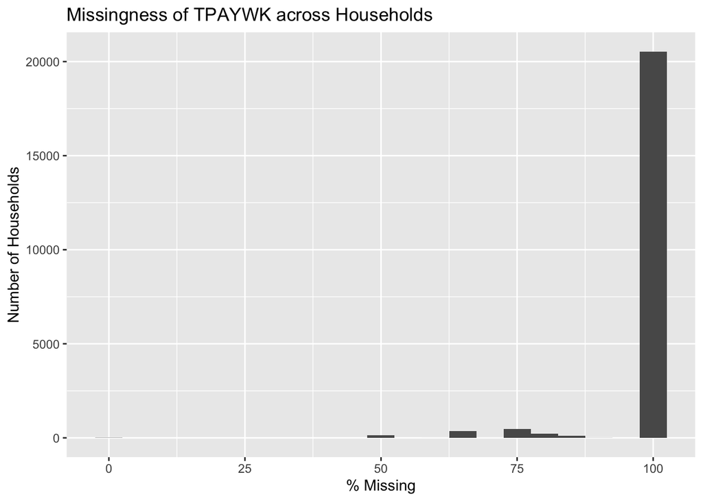

```r
# Make a list of all the variables in microsim_vars
var_list <- names(microsim_vars)

# Obtain plots of the missingness of all microsimulation variables
plots <- sapply(var_list, function(v) {
  do.call(hh_miss_hist, list(data = microsim_vars, var = as.name(v), hh_id = as.name("snap_hhid")))
}, simplify = FALSE)

# Visualize TPAYWK missingness (second highest missingness)
library(patchwork)
plots[["TPAYWK"]]
```

## Apply the function to all variables

From our earlier analysis of missingness at the indivdual-level, we found that TAGE (age), RTANF_MNYN (received TANF this month), ECITIZEN (is a citizen) are not missing for any individuals in the SIPP. RDIS (individual has a disability) and RSSI_MNYN (received SSI benefits this month) have very low levels of missingness at the individual-level. So, we will exclude these variables from this part of the EDA.

First, we examine the variables that show income and deductions: TPTOTINC (sum of personal monthly earnings for people age 15 and over), TPEARN (sum of earnings from jobs), and TMDPAY (amount paid out of pocket for medical care).

TPTOTINC and TPEARN are used to estimate gross income and earnings, respectively, and TMDPAY is used to estimate deductions for medical costs.

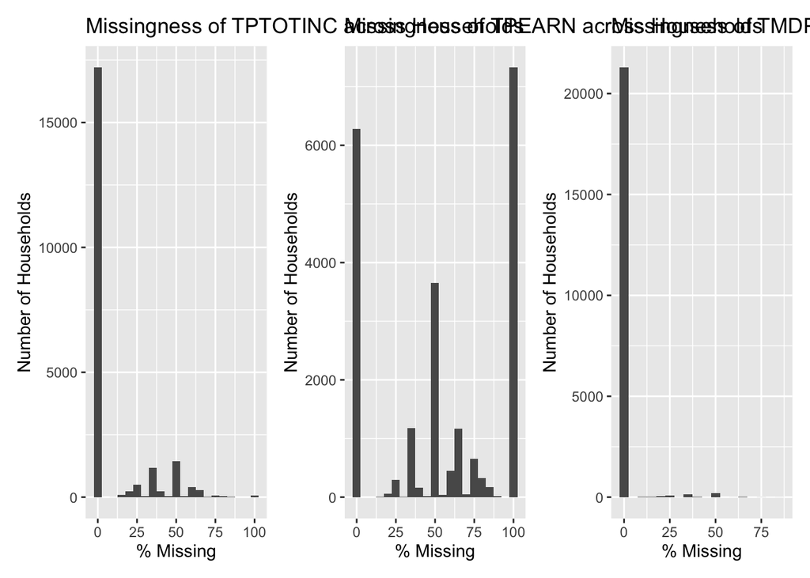

```r
# Income and deduction variables
incded_vars <- c("TPTOTINC", "TPEARN", "TMDPAY")

wrap_plots(plots[incded_vars])
```

For TPTOTINC (gross income), most households (over 15,000) are not missing anything, meaning that all individuals in the household reported income. Most households have 0% missing for TMDPAY (medical costs) as well.

Next we examine TPEARN (earnings) more closely:

```r
microsim_vars |>
  group_by(snap_hhid) |>
  summarize(pct_missing = mean(is.na(TPEARN)) * 100) |>
  count(pct_missing)
```

```
# A tibble: 32 × 2
   pct_missing     n
         <dbl> <int>
 1         0    6279
 2        14.3     2
 3        16.7     5
 4        20      57
 5        25     291
 6        28.6     3
 7        33.3  1179
 8        37.5     2
 9        40     161
10        42.9    21
# ℹ 22 more rows
```

Most households have some individuals who have missing values for their earnings from jobs.

Next, we examine the shelter and asset variables:

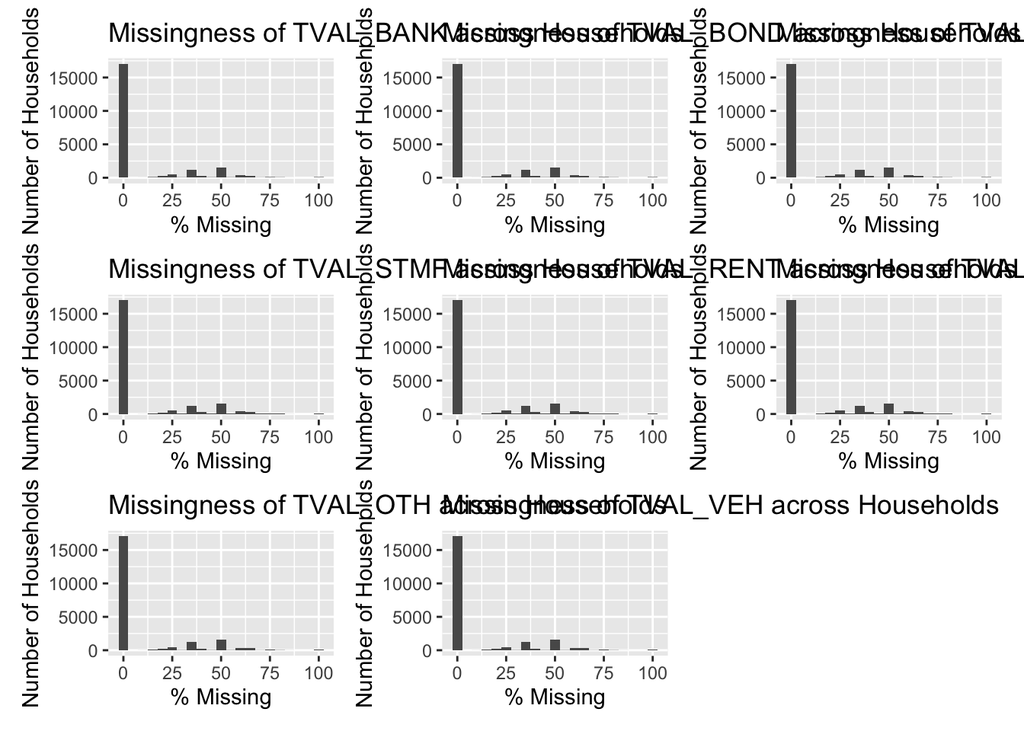

```r
# Shelter and assets
shelterasset_vars <- c("TVAL_BANK", "TVAL_BOND", "TVAL_BUS", "TVAL_STMF", "TVAL_RENT",
                       "TVAL_RE", "TVAL_OTH", "TVAL_VEH")

wrap_plots(plots[shelterasset_vars])
```

All of these variables are mostly households without any missing values at the individual level.

Next, we examine the variables we use to estimate ABAWD and vehicle assets.

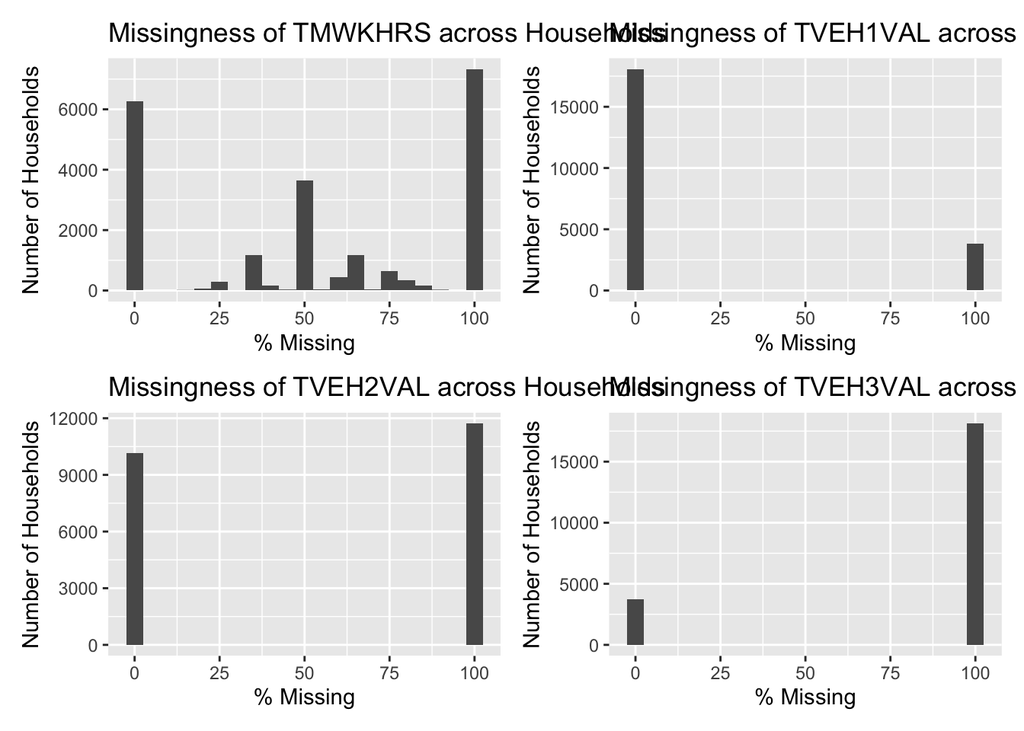

```r
# Vehicles and ABAWD vars
veh_abawd_vars <- c("TMWKHRS", "TVEH1VAL", "TVEH2VAL", "TVEH3VAL")

wrap_plots(plots[veh_abawd_vars])
```

TMWKHRS (average number of hours worked per week across all jobs) has the same missingness distribution as TPEARN because they have the same universe description (individuals who had at least one job during the reference month).

For the vehicle variables, they are either 0% missing or 100% missing in a household, which makes sense because each individual in the household would report the same information for their vehicles.